# Module 146

#### Hemi-module gene counts:

276 probesets in hemi-module A.  
66 probesets in hemi-module B.  
Note: While the mapping of probesets to genes is usually one-to-one, some genes are targeted by multiple probesets, some probesets target multiple genes, and some probesets do not target any genes (i.e., the region of the genome they match is no longer considered genic).

#### Contrast SVE:

Signed variance explained (SVE) provides an indication of how similar a set of fold changes are to a gene module’s weight vector. An SVE value of 0.3, for example, indicates that 30% of the variance explained by the entire module set is accounted for by the module in question. Shown here are the SVE values for this module across a compendium of fold changes (contrasts). Extreme SVE values (e.g., > 0.05) indicate that those contrasts specifically induce (orange dots) or specifically repress (blue dots) this module. Examining the experimental conditions being compared in such contrasts (see tables below the figure) may provide insight into the gene module’s function.

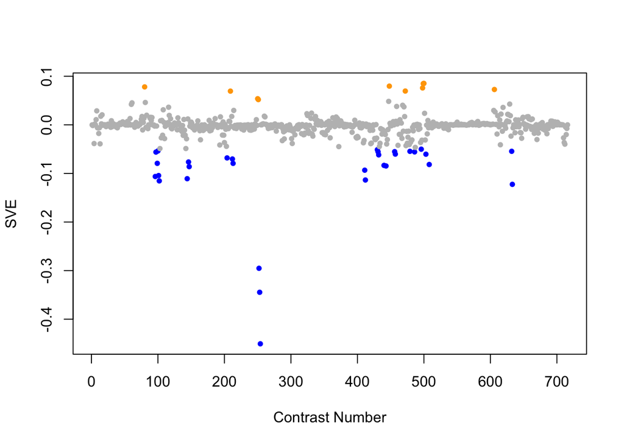

Positive SVE Contrasts:

|  | Contrast.Num | SVE | GEO.GSE | Cond.1 | Cond.2 | Mutation |
| --- | --- | --- | --- | --- | --- | --- |
| GSE23013.s2t1.vs.s0t1 | 500 | 0.09 | GSE23013 | young adult_24hr Formaldehyde exposure_rep1 | young adult_not exposed_rep1 |  |
| GSE23013.s3t1.vs.s0t1 | 499 | 0.08 | GSE23013 | young adult_24hr BTF mix exposure_rep1 | young adult_not exposed_rep1 |  |
| GSE27401.s1t1.vs.s2t1 | 448 | 0.08 | GSE27401 | Heat Killed E coli #1 | Heat Killed C. albicans #1 |  |
| GSE8004.s3t2.vs.s3t1 | 80 | 0.08 | GSE8004 | Larval Pan-neural, biological rep 1 of set 2 | Embryonic Pan-neural, biological rep 1 of set 1 |  |
| GSE23013.s4t1.vs.s0t1 | 498 | 0.08 | GSE23013 | young adult_24hr Benzene exposure_rep1 | young adult_not exposed_rep1 |  |
| GSE21784.s1t1.vs.s3t1 | 606 | 0.07 | GSE21784 | L4 larvae, biological rep1 | day 15 adults, biological rep 1 |  |
| GSE23528A.s2t2.vs.s0t2 | 472 | 0.07 | GSE23528 | Adult at T6 in WC, time-series experiment 1 | Adult at T6, non-entrained control time-series experiment 4 |  |
| GSE42689.s2t1.vs.s1t1 | 209 | 0.07 | GSE42689 | mek-1 fed 1 | mek-1 fasted 1 |  |
| GSE42192.s1t1.vs.s0t1 | 250 | 0.05 | GSE42192 | C.elegans fed with CNCM I-3690 3 days rep1 | C.elegans fed with E.coli OP50 3 days rep1 |  |
| GSE42192.s2t1.vs.s0t1 | 251 | 0.05 | GSE42192 | C.elegans fed with CNCM I-4317 3 days rep1 | C.elegans fed with E.coli OP50 3 days rep1 |  |

Negative SVE Contrasts:

|  | Contrast.Num | SVE | GEO.GSE | Cond.1 | Cond.2 | Mutation |
| --- | --- | --- | --- | --- | --- | --- |
| GSE42192.s0t2.vs.s0t1 | 254 | -0.45 | GSE42192 | C.elegans fed with E.coli OP50 10 days rep1 | C.elegans fed with E.coli OP50 3 days rep1 |  |
| GSE42192.s2t2.vs.s2t1 | 253 | -0.34 | GSE42192 | C.elegans fed with CNCM I-4317 10 days rep1 | C.elegans fed with CNCM I-4317 3 days rep1 |  |
| GSE42192.s1t2.vs.s1t1 | 252 | -0.30 | GSE42192 | C.elegans fed with CNCM I-3690 10 days rep1 | C.elegans fed with CNCM I-3690 3 days rep1 |  |
| GSE19310B.s1t3.vs.s1t1 | 633 | -0.12 | GSE19310 | N2 at 200 for 6 hours, rep1 | N2 at 200 for 15min, rep1 |  |
| GSE5793.s2t2.vs.s2t1 | 102 | -0.12 | GSE5793 | Celegans_OP50_8hours_RepA | Celegans_OP50_4hours_RepA |  |
| GSE30505.s1t2.vs.s1t1 | 412 | -0.11 | GSE30505 | Day 8 N2 (WT) E.V. #1 | L3 N2 (WT) E.V. #1 |  |
| GSE50513.s4t1.vs.s1t1 | 144 | -0.11 | GSE50513 | zip-2 PA14 - rep 1 | L4440 OP50 - rep 1 |  |
| GSE5793.s3t1.vs.s1t1 | 96 | -0.11 | GSE5793 | Celegans_PA14_4hours_RepA | Celegans_gacA_4hours_RepA |  |
| GSE5793.s1t2.vs.s1t1 | 101 | -0.10 | GSE5793 | Celegans_gacA_8hours_RepA | Celegans_gacA_4hours_RepA |  |
| GSE30505.s2t2.vs.s2t1 | 411 | -0.09 | GSE30505 | Day 8 N2 (WT) ash-2 #1 | L3 N2 (WT) ash-2 #1 |  |
| GSE50513.s4t1.vs.s3t1 | 147 | -0.09 | GSE50513 | zip-2 PA14 - rep 1 | zip-2 OP50 - rep 1 |  |
| GSE27677B.s1t3.vs.s1t1 | 443 | -0.08 | GSE27677 | N2, Fast 6 h, rep 1 | N2, Fed 0 h, rep 1 |  |
| GSE27677B.s1t2.vs.s1t1 | 440 | -0.08 | GSE27677 | N2, Fast 3 h, rep 1 | N2, Fed 0 h, rep 1 |  |
| GSE21819.s1t1.vs.s0t1 | 508 | -0.08 | GSE21819 | CELEGANS_RN6390_8H_REP1 | CELEGANS_OP50_8H_REP1 |  |
| GSE42689.s4t1.vs.s2t1 | 213 | -0.08 | GSE42689 | mlk-1 fed 1 | mek-1 fed 1 |  |
| GSE5793.s3t2.vs.s1t2 | 99 | -0.08 | GSE5793 | Celegans_PA14_8hours_RepA | Celegans_gacA_8hours_RepA |  |
| GSE50513.s4t1.vs.s2t1 | 146 | -0.08 | GSE50513 | zip-2 PA14 - rep 1 | L4440 PA14 - rep 1 | zip-2 |
| GSE42689.s3t1.vs.s2t1 | 212 | -0.07 | GSE42689 | mlk-1 fasted 1 | mek-1 fed 1 |  |
| GSE43952.s2t1.vs.s0t1 | 204 | -0.07 | GSE43952 | pcca-1(ok2282) fed Comamonas DA1877 rep1 | N2 gravid adult fed Comamonas DA1877 rep 1 | pcca-1 |
| GSE27677A.s2t2.vs.s2t1 | 432 | -0.06 | GSE27677 | jun-1, Fast , rep 1 | jun-1, Fed , rep 1 |  |
| GSE22660.s1t2.vs.s0t2 | 503 | -0.06 | GSE22660 | 1ug/ml ivermectin exposure, biological rep 1 | 1ug/ml DMSO control, biological rep 1 |  |
| GSE24847.s1t3.vs.s1t1 | 457 | -0.06 | GSE24847 | young adult_4hr MWCNT exposure_rep1 | young adult_0h MWCNT exposure_rep1 |  |
| GSE5793.s3t1.vs.s2t1 | 97 | -0.06 | GSE5793 | Celegans_PA14_4hours_RepA | Celegans_OP50_4hours_RepA |  |
| GSE23528A.s0t6.vs.s0t1 | 486 | -0.06 | GSE23528 | Adult at T22, non-entrained control time-series experiment 4 | Adult at T2, non-entrained control time-series experiment 4 |  |
| GSE27677A.s3t2.vs.s3t1 | 431 | -0.06 | GSE27677 | daf-16, Fast , rep 1 | daf-16, Fed , rep 1 |  |
| GSE24847.s1t2.vs.s1t1 | 456 | -0.06 | GSE24847 | young adult_24hr MWCNT exposure_rep1 | young adult_0h MWCNT exposure_rep1 |  |
| GSE23528A.s2t4.vs.s2t1 | 479 | -0.05 | GSE23528 | Adult at T14 in WC, time-series experiment 1 | Adult at T2 in WC, time-series experiment 1 |  |
| GSE19310B.s1t2.vs.s1t1 | 632 | -0.05 | GSE19310 | N2 at 200 for 1 hour, rep1 | N2 at 200 for 15min, rep1 |  |
| GSE5793.s3t2.vs.s2t2 | 100 | -0.05 | GSE5793 | Celegans_PA14_8hours_RepA | Celegans_OP50_8hours_RepA |  |
| GSE27677A.s1t1.vs.s0t1 | 430 | -0.05 | GSE27677 | kgb-1, Fed , rep 1 | N2, Fed , rep 1 | kgb-1 |
| GSE23528C.s1t5.vs.s1t1 | 496 | -0.05 | GSE23528 | Adult at T42 in DD, time-series experiment 2 | Adult at T26 in DD, time-series experiment 2 |  |

$~$

#### Contrast SVE, Up-Regulated Genes Only:

Calculating SVE for up-regulated and down-regulated genes separately may be more informative in many cases than projecting the up- and down- gene sets together. This is due to the fact that the weight distribution of many modules is highly skewed, indicating that only one of the hemi-modules may be biologically meaningful (i.e., a set of genes are strongly correlated by only a few genes (or none) are strongly anti-correlated to that set.)

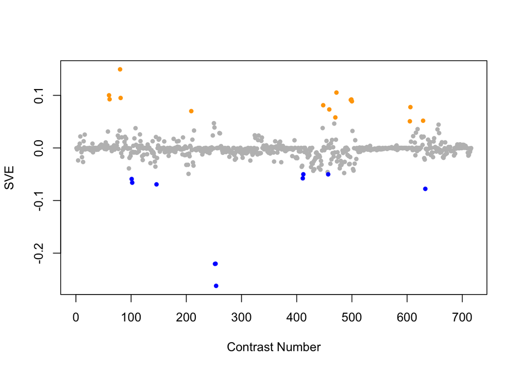

Positive SVE Contrasts:

|  | Contrast.Num | SVE | GEO.GSE | Cond.1 | Cond.2 | Mutation |
| --- | --- | --- | --- | --- | --- | --- |
| GSE8004.s3t2.vs.s3t1 | 80 | 0.15 | GSE8004 | Larval Pan-neural, biological rep 1 of set 2 | Embryonic Pan-neural, biological rep 1 of set 1 |  |
| GSE23528A.s2t2.vs.s0t2 | 472 | 0.11 | GSE23528 | Adult at T6 in WC, time-series experiment 1 | Adult at T6, non-entrained control time-series experiment 4 |  |
| GSE9301.s3t1.vs.s1t1 | 60 | 0.10 | GSE9301 | 3-day-old TJ1090 worms without any stress (C1) | 3-day-old TJ1090 worms with oxidative stress (O1) |  |
| GSE8004.s2t2.vs.s2t1 | 81 | 0.10 | GSE8004 | Larval Reference, biological rep 1 of set 1 | Embryonic Reference, biological rep 1 of set 1 |  |
| GSE9301.s3t1.vs.s2t1 | 61 | 0.09 | GSE9301 | 3-day-old TJ1090 worms without any stress (C1) | 3-day-old TJ1090 worms with skn-1 RNAi & oxidative stress (SO1) |  |
| GSE23013.s3t1.vs.s0t1 | 499 | 0.09 | GSE23013 | young adult_24hr BTF mix exposure_rep1 | young adult_not exposed_rep1 |  |
| GSE23013.s4t1.vs.s0t1 | 498 | 0.09 | GSE23013 | young adult_24hr Benzene exposure_rep1 | young adult_not exposed_rep1 |  |
| GSE23013.s2t1.vs.s0t1 | 500 | 0.09 | GSE23013 | young adult_24hr Formaldehyde exposure_rep1 | young adult_not exposed_rep1 |  |
| GSE27401.s1t1.vs.s2t1 | 448 | 0.08 | GSE27401 | Heat Killed E coli #1 | Heat Killed C. albicans #1 |  |
| GSE21784.s1t1.vs.s3t1 | 606 | 0.08 | GSE21784 | L4 larvae, biological rep1 | day 15 adults, biological rep 1 |  |
| GSE23843B.s1t1.vs.s0t1 | 459 | 0.07 | GSE23843 | RNP-8 rnp-8(q784)-IP, biological replicate 1 | RNP-8 wt-IP, biological replicate 1 |  |
| GSE42689.s2t1.vs.s1t1 | 209 | 0.07 | GSE42689 | mek-1 fed 1 | mek-1 fasted 1 |  |
| GSE23528A.s2t6.vs.s0t6 | 470 | 0.06 | GSE23528 | Adult at T22 in WC, time-series experiment 1 | Adult at T22, non-entrained control time-series experiment 4 |  |
| GSE19310A.s2t1.vs.s0t1 | 629 | 0.05 | GSE19310 | osm-7(n1515) at iso, rep1 | N2 at iso, rep1 | osm-7 |
| GSE21784.s2t1.vs.s3t1 | 605 | 0.05 | GSE21784 | day 6 adults, biological rep 1 | day 15 adults, biological rep 1 |  |

Negative SVE Contrasts:

|  | Contrast.Num | SVE | GEO.GSE | Cond.1 | Cond.2 | Mutation |
| --- | --- | --- | --- | --- | --- | --- |
| GSE42192.s0t2.vs.s0t1 | 254 | -0.26 | GSE42192 | C.elegans fed with E.coli OP50 10 days rep1 | C.elegans fed with E.coli OP50 3 days rep1 |  |
| GSE42192.s1t2.vs.s1t1 | 252 | -0.22 | GSE42192 | C.elegans fed with CNCM I-3690 10 days rep1 | C.elegans fed with CNCM I-3690 3 days rep1 |  |
| GSE42192.s2t2.vs.s2t1 | 253 | -0.22 | GSE42192 | C.elegans fed with CNCM I-4317 10 days rep1 | C.elegans fed with CNCM I-4317 3 days rep1 |  |
| GSE19310B.s1t3.vs.s1t1 | 633 | -0.08 | GSE19310 | N2 at 200 for 6 hours, rep1 | N2 at 200 for 15min, rep1 |  |
| GSE50513.s4t1.vs.s2t1 | 146 | -0.07 | GSE50513 | zip-2 PA14 - rep 1 | L4440 PA14 - rep 1 | zip-2 |
| GSE5793.s2t2.vs.s2t1 | 102 | -0.07 | GSE5793 | Celegans_OP50_8hours_RepA | Celegans_OP50_4hours_RepA |  |
| GSE5793.s1t2.vs.s1t1 | 101 | -0.06 | GSE5793 | Celegans_gacA_8hours_RepA | Celegans_gacA_4hours_RepA |  |
| GSE30505.s2t2.vs.s2t1 | 411 | -0.06 | GSE30505 | Day 8 N2 (WT) ash-2 #1 | L3 N2 (WT) ash-2 #1 |  |
| GSE24847.s1t3.vs.s1t1 | 457 | -0.05 | GSE24847 | young adult_4hr MWCNT exposure_rep1 | young adult_0h MWCNT exposure_rep1 |  |
| GSE30505.s1t2.vs.s1t1 | 412 | -0.05 | GSE30505 | Day 8 N2 (WT) E.V. #1 | L3 N2 (WT) E.V. #1 |  |

$~$

#### Contrast SVE, Down-Regulated Genes Only:

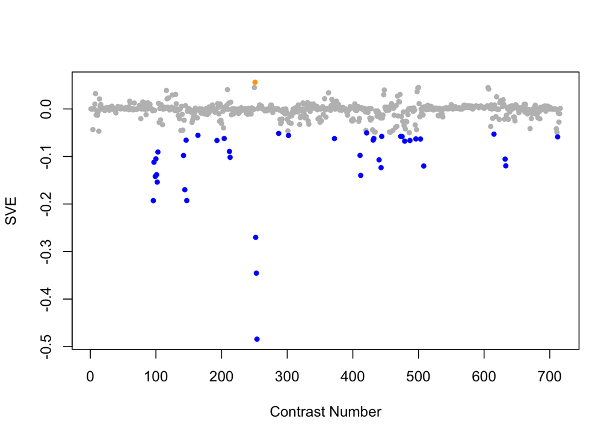

Positive SVE Contrasts:

|  | Contrast.Num | SVE | GEO.GSE | Cond.1 | Cond.2 | Mutation |
| --- | --- | --- | --- | --- | --- | --- |
| GSE42192.s2t1.vs.s0t1 | 251 | 0.06 | GSE42192 | C.elegans fed with CNCM I-4317 3 days rep1 | C.elegans fed with E.coli OP50 3 days rep1 |  |
| GSE42192.s1t1.vs.s0t1 | 250 | 0.05 | GSE42192 | C.elegans fed with CNCM I-3690 3 days rep1 | C.elegans fed with E.coli OP50 3 days rep1 |  |
| GSE23013.s2t1.vs.s0t1 | 500 | 0.05 | GSE23013 | young adult_24hr Formaldehyde exposure_rep1 | young adult_not exposed_rep1 |  |
| GSE21784.s1t1.vs.s3t1 | 606 | 0.04 | GSE21784 | L4 larvae, biological rep1 | day 15 adults, biological rep 1 |  |
| GSE23013.s3t1.vs.s0t1 | 499 | 0.04 | GSE23013 | young adult_24hr BTF mix exposure_rep1 | young adult_not exposed_rep1 |  |

Negative SVE Contrasts:

|  | Contrast.Num | SVE | GEO.GSE | Cond.1 | Cond.2 | Mutation |
| --- | --- | --- | --- | --- | --- | --- |
| GSE42192.s0t2.vs.s0t1 | 254 | -0.48 | GSE42192 | C.elegans fed with E.coli OP50 10 days rep1 | C.elegans fed with E.coli OP50 3 days rep1 |  |
| GSE42192.s2t2.vs.s2t1 | 253 | -0.35 | GSE42192 | C.elegans fed with CNCM I-4317 10 days rep1 | C.elegans fed with CNCM I-4317 3 days rep1 |  |
| GSE42192.s1t2.vs.s1t1 | 252 | -0.27 | GSE42192 | C.elegans fed with CNCM I-3690 10 days rep1 | C.elegans fed with CNCM I-3690 3 days rep1 |  |
| GSE5793.s3t1.vs.s1t1 | 96 | -0.19 | GSE5793 | Celegans_PA14_4hours_RepA | Celegans_gacA_4hours_RepA |  |
| GSE50513.s4t1.vs.s3t1 | 147 | -0.19 | GSE50513 | zip-2 PA14 - rep 1 | zip-2 OP50 - rep 1 |  |
| GSE50513.s4t1.vs.s1t1 | 144 | -0.17 | GSE50513 | zip-2 PA14 - rep 1 | L4440 OP50 - rep 1 |  |
| GSE5793.s2t2.vs.s2t1 | 102 | -0.15 | GSE5793 | Celegans_OP50_8hours_RepA | Celegans_OP50_4hours_RepA |  |
| GSE5793.s3t2.vs.s1t2 | 99 | -0.14 | GSE5793 | Celegans_PA14_8hours_RepA | Celegans_gacA_8hours_RepA |  |
| GSE30505.s1t2.vs.s1t1 | 412 | -0.14 | GSE30505 | Day 8 N2 (WT) E.V. #1 | L3 N2 (WT) E.V. #1 |  |
| GSE5793.s1t2.vs.s1t1 | 101 | -0.14 | GSE5793 | Celegans_gacA_8hours_RepA | Celegans_gacA_4hours_RepA |  |
| GSE27677B.s1t3.vs.s1t1 | 443 | -0.12 | GSE27677 | N2, Fast 6 h, rep 1 | N2, Fed 0 h, rep 1 |  |
| GSE21819.s1t1.vs.s0t1 | 508 | -0.12 | GSE21819 | CELEGANS_RN6390_8H_REP1 | CELEGANS_OP50_8H_REP1 |  |
| GSE19310B.s1t3.vs.s1t1 | 633 | -0.12 | GSE19310 | N2 at 200 for 6 hours, rep1 | N2 at 200 for 15min, rep1 |  |
| GSE5793.s3t1.vs.s2t1 | 97 | -0.11 | GSE5793 | Celegans_PA14_4hours_RepA | Celegans_OP50_4hours_RepA |  |
| GSE27677B.s1t2.vs.s1t1 | 440 | -0.11 | GSE27677 | N2, Fast 3 h, rep 1 | N2, Fed 0 h, rep 1 |  |
| GSE19310B.s1t2.vs.s1t1 | 632 | -0.11 | GSE19310 | N2 at 200 for 1 hour, rep1 | N2 at 200 for 15min, rep1 |  |
| GSE5793.s3t2.vs.s2t2 | 100 | -0.10 | GSE5793 | Celegans_PA14_8hours_RepA | Celegans_OP50_8hours_RepA |  |
| GSE42689.s4t1.vs.s2t1 | 213 | -0.10 | GSE42689 | mlk-1 fed 1 | mek-1 fed 1 |  |
| GSE50513.s2t1.vs.s1t1 | 142 | -0.10 | GSE50513 | L4440 PA14 - rep 1 | L4440 OP50 - rep 1 |  |
| GSE30505.s2t2.vs.s2t1 | 411 | -0.10 | GSE30505 | Day 8 N2 (WT) ash-2 #1 | L3 N2 (WT) ash-2 #1 |  |
| GSE5793.s3t2.vs.s3t1 | 103 | -0.09 | GSE5793 | Celegans_PA14_8hours_RepA | Celegans_PA14_4hours_RepA |  |
| GSE42689.s3t1.vs.s2t1 | 212 | -0.09 | GSE42689 | mlk-1 fasted 1 | mek-1 fed 1 |  |
| GSE23528A.s2t4.vs.s2t1 | 479 | -0.07 | GSE23528 | Adult at T14 in WC, time-series experiment 1 | Adult at T2 in WC, time-series experiment 1 |  |
| GSE45292.s1t1.vs.s0t1 | 193 | -0.07 | GSE45292 | N2 Rifampicin, Biological rep1 | N2 DMSO, Biological rep1 |  |
| GSE23528A.s0t2.vs.s0t1 | 487 | -0.07 | GSE23528 | Adult at T6, non-entrained control time-series experiment 4 | Adult at T2, non-entrained control time-series experiment 4 |  |
| GSE50513.s4t1.vs.s2t1 | 146 | -0.07 | GSE50513 | zip-2 PA14 - rep 1 | L4440 PA14 - rep 1 | zip-2 |
| GSE27677A.s3t2.vs.s3t1 | 431 | -0.07 | GSE27677 | daf-16, Fast , rep 1 | daf-16, Fed , rep 1 |  |
| GSE22660.s1t2.vs.s0t2 | 503 | -0.06 | GSE22660 | 1ug/ml ivermectin exposure, biological rep 1 | 1ug/ml DMSO control, biological rep 1 |  |
| GSE23528C.s1t5.vs.s1t1 | 496 | -0.06 | GSE23528 | Adult at T42 in DD, time-series experiment 2 | Adult at T26 in DD, time-series experiment 2 |  |
| GSE35360C.s2t1.vs.s0t1 | 372 | -0.06 | GSE35360 | HFHQ 3d_2.0_rep1 | HFHQ 3d control_rep1 |  |
| GSE43952.s2t1.vs.s0t1 | 204 | -0.06 | GSE43952 | pcca-1(ok2282) fed Comamonas DA1877 rep1 | N2 gravid adult fed Comamonas DA1877 rep 1 | pcca-1 |
| GSE27677A.s2t2.vs.s2t1 | 432 | -0.06 | GSE27677 | jun-1, Fast , rep 1 | jun-1, Fed , rep 1 |  |
| GSE11055.s2t8.vs.s2t2 | 712 | -0.06 | GSE11055 | L1 larvae 24 hr after hatching in the absence of food | L1 larvae 0 hr after hatching in the absence of food |  |
| GSE23528A.s1t5.vs.s1t1 | 475 | -0.06 | GSE23528 | Adult at T18 in LD, time-series experiment 3 | Adult at T2 in LD, time-series experiment 3 |  |
| GSE23528A.s1t3.vs.s1t1 | 473 | -0.06 | GSE23528 | Adult at T10 in LD, time-series experiment 3 | Adult at T2 in LD, time-series experiment 3 |  |
| GSE27677B.s1t4.vs.s1t1 | 444 | -0.06 | GSE27677 | N2, Fast 9 h, rep 1 | N2, Fed 0 h, rep 1 |  |
| GSE41366C.s2t5.vs.s2t1 | 302 | -0.06 | GSE41366 | high_DDVP-continuous_expose-26h_harvest-rep1 | high_DDVP-continuous_expose-2h_harvest-rep1 |  |
| GSE47778.s1t2.vs.s2t2 | 164 | -0.06 | GSE47778 | N2; starvation; replicate 1 | daf-2; starvation; replicate 1 | daf-2 |
| GSE21591.s1t1.vs.s4t1 | 615 | -0.05 | GSE21591 | N2_aFLAG_1 | aMYC_1 |  |
| GSE41366C.s2t4.vs.s0t4 | 287 | -0.05 | GSE41366 | high_DDVP-continuous_expose-20h_harvest-rep1 | control-continuous_expose-14h_harvest-rep1 |  |
| GSE28494.s1t2.vs.s0t2 | 421 | -0.05 | GSE28494 | lin-54(n3423) dissected germline 1 | wild-type N2 dissected germline 1 | lin-54 |

$~$

$~$

#### GO Term Enrichment:

This analysis tests each hemi-module for enrichment of specific GO terms. Only gene-level annotations (e.g., as would be found on the gene’s page in Wormbase) are tested - the hierarchical structure of the GO ontology is not taken into account.

*Note: At least the top two most enriched terms from each GO domain (BP/MF/CC) are shown, even when not statistically significant.*

##### Enriched GO terms: Hemi-module A

| ID | GO.Term | GO Domain | Raw p-value | Adj p-value |
| --- | --- | --- | --- | --- |
| [GO_0055085](http://amigo.geneontology.org/amigo/term/GO:0055085) | transmembrane transport | BP | 9.58e-07 | 3.49e-03 |
| [GO_0006548](http://amigo.geneontology.org/amigo/term/GO:0006548) | histidine catabolic process | BP | 3.94e-06 | 4.78e-03 |
| [GO_0019556](http://amigo.geneontology.org/amigo/term/GO:0019556) | histidine catabolic process to glutamate and formamide | BP | 3.94e-06 | 4.78e-03 |
| [GO_0009435](http://amigo.geneontology.org/amigo/term/GO:0009435) | NAD biosynthetic process | BP | 7.29e-06 | 6.64e-03 |
| [GO_0040002](http://amigo.geneontology.org/amigo/term/GO:0040002) | collagen and cuticulin-based cuticle development | BP | 2.02e-05 | 1.47e-02 |
| [GO_1902600](http://amigo.geneontology.org/amigo/term/GO:1902600) | proton transmembrane transport | BP | 2.73e-05 | 1.66e-02 |
| [GO_0006569](http://amigo.geneontology.org/amigo/term/GO:0006569) | tryptophan catabolic process | BP | 3.85e-05 | 1.79e-02 |
| [GO_0042338](http://amigo.geneontology.org/amigo/term/GO:0042338) | cuticle development involved in collagen and cuticulin-based cuticle molting cycle | BP | 3.93e-05 | 1.79e-02 |
| [GO_0019363](http://amigo.geneontology.org/amigo/term/GO:0019363) | pyridine nucleotide biosynthetic process | BP | 7.60e-05 | 3.08e-02 |
| [GO_0030198](http://amigo.geneontology.org/amigo/term/GO:0030198) | extracellular matrix organization | BP | 2.11e-04 | 7.03e-02 |
| [GO_0006096](http://amigo.geneontology.org/amigo/term/GO:0006096) | glycolytic process | BP | 2.44e-04 | 7.03e-02 |
| [GO_0006547](http://amigo.geneontology.org/amigo/term/GO:0006547) | histidine metabolic process | BP | 2.51e-04 | 7.03e-02 |
| [GO_0019557](http://amigo.geneontology.org/amigo/term/GO:0019557) | histidine catabolic process to glutamate and formate | BP | 2.51e-04 | 7.03e-02 |
| [GO_0006355](http://amigo.geneontology.org/amigo/term/GO:0006355) | regulation of transcription, DNA-templated | BP | 2.87e-04 | 7.24e-02 |
| [GO_0006936](http://amigo.geneontology.org/amigo/term/GO:0006936) | muscle contraction | BP | 2.98e-04 | 7.24e-02 |
| [GO_0042302](http://amigo.geneontology.org/amigo/term/GO:0042302) | structural constituent of cuticle | MF | 1.60e-36 | 3.26e-33 |
| [GO_0015078](http://amigo.geneontology.org/amigo/term/GO:0015078) | proton transmembrane transporter activity | MF | 6.25e-09 | 6.38e-06 |
| [GO_0046961](http://amigo.geneontology.org/amigo/term/GO:0046961) | proton-transporting ATPase activity, rotational mechanism | MF | 1.04e-07 | 7.07e-05 |
| [GO_0005201](http://amigo.geneontology.org/amigo/term/GO:0005201) | extracellular matrix structural constituent | MF | 5.18e-06 | 2.65e-03 |
| [GO_0008553](http://amigo.geneontology.org/amigo/term/GO:0008553) | proton-exporting ATPase activity, phosphorylative mechanism | MF | 7.60e-05 | 2.81e-02 |
| [GO_0003677](http://amigo.geneontology.org/amigo/term/GO:0003677) | DNA binding | MF | 8.81e-05 | 2.81e-02 |
| [GO_0016620](http://amigo.geneontology.org/amigo/term/GO:0016620) | oxidoreductase activity, acting on the aldehyde or oxo group of donors, NAD or NADP as acceptor | MF | 9.64e-05 | 2.81e-02 |
| [GO_0004365](http://amigo.geneontology.org/amigo/term/GO:0004365) | glyceraldehyde-3-phosphate dehydrogenase (NAD+) (phosphorylating) activity | MF | 2.51e-04 | 5.96e-02 |
| [GO_0016491](http://amigo.geneontology.org/amigo/term/GO:0016491) | oxidoreductase activity | MF | 2.88e-04 | 5.96e-02 |
| [GO_0003824](http://amigo.geneontology.org/amigo/term/GO:0003824) | catalytic activity | MF | 2.92e-04 | 5.96e-02 |
| [GO_0005581](http://amigo.geneontology.org/amigo/term/GO:0005581) | collagen trimer | CC | 2.83e-16 | 2.63e-13 |
| [GO_0005634](http://amigo.geneontology.org/amigo/term/GO:0005634) | nucleus | CC | 2.96e-11 | 1.37e-08 |
| [GO_0016471](http://amigo.geneontology.org/amigo/term/GO:0016471) | vacuolar proton-transporting V-type ATPase complex | CC | 2.08e-06 | 6.42e-04 |
| [GO_0031012](http://amigo.geneontology.org/amigo/term/GO:0031012) | extracellular matrix | CC | 3.12e-05 | 7.24e-03 |
| [GO_0030056](http://amigo.geneontology.org/amigo/term/GO:0030056) | hemidesmosome | CC | 3.93e-05 | 7.30e-03 |
| [GO_0000220](http://amigo.geneontology.org/amigo/term/GO:0000220) | vacuolar proton-transporting V-type ATPase, V0 domain | CC | 7.60e-05 | 1.18e-02 |
| [GO_0005615](http://amigo.geneontology.org/amigo/term/GO:0005615) | extracellular space | CC | 3.87e-04 | 5.05e-02 |
| [GO_0005861](http://amigo.geneontology.org/amigo/term/GO:0005861) | troponin complex | CC | 4.35e-04 | 5.05e-02 |
| [GO_0005859](http://amigo.geneontology.org/amigo/term/GO:0005859) | muscle myosin complex | CC | 7.44e-04 | 7.67e-02 |
| [GO_0016324](http://amigo.geneontology.org/amigo/term/GO:0016324) | apical plasma membrane | CC | 9.69e-04 | 8.99e-02 |

##### Enriched GO terms: Hemi-module B

| ID | GO.Term | GO Domain | Raw p-value | Adj p-value |
| --- | --- | --- | --- | --- |
| [GO_0001732](http://amigo.geneontology.org/amigo/term/GO:0001732) | formation of cytoplasmic translation initiation complex | BP | 9.06e-04 | 1.00e+00 |
| [GO_0002183](http://amigo.geneontology.org/amigo/term/GO:0002183) | cytoplasmic translational initiation | BP | 9.06e-04 | 1.00e+00 |
| [GO_0004788](http://amigo.geneontology.org/amigo/term/GO:0004788) | thiamine diphosphokinase activity | MF | 3.49e-03 | 1.00e+00 |
| [GO_0008276](http://amigo.geneontology.org/amigo/term/GO:0008276) | protein methyltransferase activity | MF | 3.49e-03 | 1.00e+00 |
| [GO_0005615](http://amigo.geneontology.org/amigo/term/GO:0005615) | extracellular space | CC | 3.28e-04 | 1.49e-01 |
| [GO_0016020](http://amigo.geneontology.org/amigo/term/GO:0016020) | membrane | CC | 3.33e-04 | 1.49e-01 |

$~$

$~$

#### Tissue Enrichment:

This analysis tests each hemi-module for enrichment of genes associated with anatomy terms. Negative enrichment scores indicate fewer hemi-module genes than expected by random chance were associated with the anatomy term in question.

##### Enriched tissues: Hemi-module A

| ID | Anatomy.Term | Definition | Raw p-value | Adj p-value |
| --- | --- | --- | --- | --- |
| [WBbt_0005733](https://wormbase.org/species/all/anatomy_term/WBbt:0005733) | hypodermis | Epidermal layer. | 5.44e-09 | 1.32e-05 |

##### Enriched tissues: Hemi-module B

No significant annotations.

$~$

$~$

#### HOMER promoter motif enrichment:

This analysis tests each hemi-module for enrichment of 108 known *C. elegans* transcription factor binding site motifs (see [108 CE motifs](https://katiepod.github.io//all.worm.motifs.html)) using the HOMER (Hypergeometric Optimization of Motif EnRichment) software (see [PMID:20513432](https://pubmed.ncbi.nlm.nih.gov/20513432)). HOMER was run using default parameters on sequences 1 kb upstream of the transcription start site.

##### Motif enrichment: Hemi-module A

Total target sequences = 225  
Total background sequences = 39885  
* - possible false positive

Rank

Motif

P-value

log P-pvalue

% of Targets

% of Background

STD(Bg STD)

Best Match/Details

Motif File

1

[figure not shown]

1e-17

-4.090e+01

9.33%

0.58%

169.9bp (363.4bp)

POL012.1_TATA-Box/Jaspar(0.787)  
[More Information](https://katiepod.github.io/HomerResults/m146_a_hemi_genes.txt.out.1kb/homerResults/motif1.info.html) | [Similar Motifs Found](https://katiepod.github.io/HomerResults/m146_a_hemi_genes.txt.out.1kb/homerResults/motif1.similar.html)

[motif file (matrix)](https://katiepod.github.io/HomerResults/m146_a_hemi_genes.txt.out.1kb/homerResults/motif1.motif)

2 *

[figure not shown]

1e-11

-2.675e+01

2.67%

0.01%

206.9bp (220.9bp)

vab-7/MA0927.1/Jaspar(0.596)  
[More Information](https://katiepod.github.io/HomerResults/m146_a_hemi_genes.txt.out.1kb/homerResults/motif2.info.html) | [Similar Motifs Found](https://katiepod.github.io/HomerResults/m146_a_hemi_genes.txt.out.1kb/homerResults/motif2.similar.html)

[motif file (matrix)](https://katiepod.github.io/HomerResults/m146_a_hemi_genes.txt.out.1kb/homerResults/motif2.motif)

3 *

[figure not shown]

1e-11

-2.622e+01

20.44%

6.46%

293.7bp (323.9bp)

elt-3/MA0542.1/Jaspar(0.920)  
[More Information](https://katiepod.github.io/HomerResults/m146_a_hemi_genes.txt.out.1kb/homerResults/motif3.info.html) | [Similar Motifs Found](https://katiepod.github.io/HomerResults/m146_a_hemi_genes.txt.out.1kb/homerResults/motif3.similar.html)

[motif file (matrix)](https://katiepod.github.io/HomerResults/m146_a_hemi_genes.txt.out.1kb/homerResults/motif3.motif)

4 *

[figure not shown]

1e-10

-2.513e+01

50.67%

29.15%

294.6bp (324.6bp)

POL012.1_TATA-Box/Jaspar(0.738)  
[More Information](https://katiepod.github.io/HomerResults/m146_a_hemi_genes.txt.out.1kb/homerResults/motif4.info.html) | [Similar Motifs Found](https://katiepod.github.io/HomerResults/m146_a_hemi_genes.txt.out.1kb/homerResults/motif4.similar.html)

[motif file (matrix)](https://katiepod.github.io/HomerResults/m146_a_hemi_genes.txt.out.1kb/homerResults/motif4.motif)

5 *

[figure not shown]

1e-10

-2.491e+01

5.33%

0.30%

311.0bp (276.4bp)

POL010.1_DCE_S_III/Jaspar(0.529)  
[More Information](https://katiepod.github.io/HomerResults/m146_a_hemi_genes.txt.out.1kb/homerResults/motif5.info.html) | [Similar Motifs Found](https://katiepod.github.io/HomerResults/m146_a_hemi_genes.txt.out.1kb/homerResults/motif5.similar.html)

[motif file (matrix)](https://katiepod.github.io/HomerResults/m146_a_hemi_genes.txt.out.1kb/homerResults/motif5.motif)

6 *

[figure not shown]

1e-10

-2.473e+01

8.44%

1.10%

271.0bp (326.3bp)

lin-54/MA1450.1/Jaspar(0.609)  
[More Information](https://katiepod.github.io/HomerResults/m146_a_hemi_genes.txt.out.1kb/homerResults/motif6.info.html) | [Similar Motifs Found](https://katiepod.github.io/HomerResults/m146_a_hemi_genes.txt.out.1kb/homerResults/motif6.similar.html)

[motif file (matrix)](https://katiepod.github.io/HomerResults/m146_a_hemi_genes.txt.out.1kb/homerResults/motif6.motif)

7 *

[figure not shown]

1e-10

-2.397e+01

4.89%

0.25%

280.6bp (299.4bp)

POL012.1_TATA-Box/Jaspar(0.575)  
[More Information](https://katiepod.github.io/HomerResults/m146_a_hemi_genes.txt.out.1kb/homerResults/motif7.info.html) | [Similar Motifs Found](https://katiepod.github.io/HomerResults/m146_a_hemi_genes.txt.out.1kb/homerResults/motif7.similar.html)

[motif file (matrix)](https://katiepod.github.io/HomerResults/m146_a_hemi_genes.txt.out.1kb/homerResults/motif7.motif)

8 *

[figure not shown]

1e-10

-2.331e+01

5.78%

0.45%

278.4bp (296.1bp)

ceh-48/MA0921.1/Jaspar(0.586)  
[More Information](https://katiepod.github.io/HomerResults/m146_a_hemi_genes.txt.out.1kb/homerResults/motif8.info.html) | [Similar Motifs Found](https://katiepod.github.io/HomerResults/m146_a_hemi_genes.txt.out.1kb/homerResults/motif8.similar.html)

[motif file (matrix)](https://katiepod.github.io/HomerResults/m146_a_hemi_genes.txt.out.1kb/homerResults/motif8.motif)

9 *

[figure not shown]

1e-9

-2.285e+01

4.89%

0.28%

312.1bp (312.6bp)

MF0002.1_bZIP_CREB/G-box-like_subclass/Jaspar(0.527)  
[More Information](https://katiepod.github.io/HomerResults/m146_a_hemi_genes.txt.out.1kb/homerResults/motif9.info.html) | [Similar Motifs Found](https://katiepod.github.io/HomerResults/m146_a_hemi_genes.txt.out.1kb/homerResults/motif9.similar.html)

[motif file (matrix)](https://katiepod.github.io/HomerResults/m146_a_hemi_genes.txt.out.1kb/homerResults/motif9.motif)

10 *

[figure not shown]

1e-9

-2.208e+01

4.89%

0.30%

185.2bp (333.1bp)

GEI-11(Myb?)/cElegans-L4-GEI11-ChIP-Seq(modEncode)/Homer(0.555)  
[More Information](https://katiepod.github.io/HomerResults/m146_a_hemi_genes.txt.out.1kb/homerResults/motif10.info.html) | [Similar Motifs Found](https://katiepod.github.io/HomerResults/m146_a_hemi_genes.txt.out.1kb/homerResults/motif10.similar.html)

[motif file (matrix)](https://katiepod.github.io/HomerResults/m146_a_hemi_genes.txt.out.1kb/homerResults/motif10.motif)

11 *

[figure not shown]

1e-9

-2.173e+01

12.44%

3.00%

201.6bp (341.6bp)

LIN-39(Homeobox)/cElegans.L3-LIN39-ChIP-Seq(modEncode)/Homer(0.636)  
[More Information](https://katiepod.github.io/HomerResults/m146_a_hemi_genes.txt.out.1kb/homerResults/motif11.info.html) | [Similar Motifs Found](https://katiepod.github.io/HomerResults/m146_a_hemi_genes.txt.out.1kb/homerResults/motif11.similar.html)

[motif file (matrix)](https://katiepod.github.io/HomerResults/m146_a_hemi_genes.txt.out.1kb/homerResults/motif11.motif)

12 *

[figure not shown]

1e-9

-2.137e+01

8.00%

1.20%

246.5bp (321.0bp)

MF0004.1_Nuclear_Receptor_class/Jaspar(0.705)  
[More Information](https://katiepod.github.io/HomerResults/m146_a_hemi_genes.txt.out.1kb/homerResults/motif12.info.html) | [Similar Motifs Found](https://katiepod.github.io/HomerResults/m146_a_hemi_genes.txt.out.1kb/homerResults/motif12.similar.html)

[motif file (matrix)](https://katiepod.github.io/HomerResults/m146_a_hemi_genes.txt.out.1kb/homerResults/motif12.motif)

13 *

[figure not shown]

1e-9

-2.111e+01

46.67%

27.43%

292.5bp (319.5bp)

blmp-1/MA0537.1/Jaspar(0.628)  
[More Information](https://katiepod.github.io/HomerResults/m146_a_hemi_genes.txt.out.1kb/homerResults/motif13.info.html) | [Similar Motifs Found](https://katiepod.github.io/HomerResults/m146_a_hemi_genes.txt.out.1kb/homerResults/motif13.similar.html)

[motif file (matrix)](https://katiepod.github.io/HomerResults/m146_a_hemi_genes.txt.out.1kb/homerResults/motif13.motif)

14 *

[figure not shown]

1e-9

-2.075e+01

5.33%

0.45%

325.9bp (333.3bp)

fkh-9/MA1440.1/Jaspar(0.624)  
[More Information](https://katiepod.github.io/HomerResults/m146_a_hemi_genes.txt.out.1kb/homerResults/motif14.info.html) | [Similar Motifs Found](https://katiepod.github.io/HomerResults/m146_a_hemi_genes.txt.out.1kb/homerResults/motif14.similar.html)

[motif file (matrix)](https://katiepod.github.io/HomerResults/m146_a_hemi_genes.txt.out.1kb/homerResults/motif14.motif)

15 *

[figure not shown]

1e-9

-2.072e+01

27.11%

12.10%

266.1bp (332.7bp)

fkh-9/MA1440.1/Jaspar(0.603)  
[More Information](https://katiepod.github.io/HomerResults/m146_a_hemi_genes.txt.out.1kb/homerResults/motif15.info.html) | [Similar Motifs Found](https://katiepod.github.io/HomerResults/m146_a_hemi_genes.txt.out.1kb/homerResults/motif15.similar.html)

[motif file (matrix)](https://katiepod.github.io/HomerResults/m146_a_hemi_genes.txt.out.1kb/homerResults/motif15.motif)

16 *

[figure not shown]

1e-8

-2.064e+01

9.78%

1.95%

271.6bp (327.7bp)

PL0012.1_hlh-2::hlh-8/Jaspar(0.552)  
[More Information](https://katiepod.github.io/HomerResults/m146_a_hemi_genes.txt.out.1kb/homerResults/motif16.info.html) | [Similar Motifs Found](https://katiepod.github.io/HomerResults/m146_a_hemi_genes.txt.out.1kb/homerResults/motif16.similar.html)

[motif file (matrix)](https://katiepod.github.io/HomerResults/m146_a_hemi_genes.txt.out.1kb/homerResults/motif16.motif)

17 *

[figure not shown]

1e-8

-2.027e+01

8.00%

1.29%

346.5bp (306.9bp)

lin-54/MA1450.1/Jaspar(0.596)  
[More Information](https://katiepod.github.io/HomerResults/m146_a_hemi_genes.txt.out.1kb/homerResults/motif17.info.html) | [Similar Motifs Found](https://katiepod.github.io/HomerResults/m146_a_hemi_genes.txt.out.1kb/homerResults/motif17.similar.html)

[motif file (matrix)](https://katiepod.github.io/HomerResults/m146_a_hemi_genes.txt.out.1kb/homerResults/motif17.motif)

18 *

[figure not shown]

1e-8

-2.007e+01

13.33%

3.69%

257.1bp (319.4bp)

PL0005.1_hlh-30/Jaspar(0.834)  
[More Information](https://katiepod.github.io/HomerResults/m146_a_hemi_genes.txt.out.1kb/homerResults/motif18.info.html) | [Similar Motifs Found](https://katiepod.github.io/HomerResults/m146_a_hemi_genes.txt.out.1kb/homerResults/motif18.similar.html)

[motif file (matrix)](https://katiepod.github.io/HomerResults/m146_a_hemi_genes.txt.out.1kb/homerResults/motif18.motif)

19 *

[figure not shown]

1e-8

-1.944e+01

4.00%

0.22%

286.9bp (356.8bp)

skn-1/MA0547.1/Jaspar(0.626)  
[More Information](https://katiepod.github.io/HomerResults/m146_a_hemi_genes.txt.out.1kb/homerResults/motif19.info.html) | [Similar Motifs Found](https://katiepod.github.io/HomerResults/m146_a_hemi_genes.txt.out.1kb/homerResults/motif19.similar.html)

[motif file (matrix)](https://katiepod.github.io/HomerResults/m146_a_hemi_genes.txt.out.1kb/homerResults/motif19.motif)

20 *

[figure not shown]

1e-8

-1.874e+01

5.33%

0.54%

300.0bp (313.0bp)

PL0008.1_hlh-29/Jaspar(0.604)  
[More Information](https://katiepod.github.io/HomerResults/m146_a_hemi_genes.txt.out.1kb/homerResults/motif20.info.html) | [Similar Motifs Found](https://katiepod.github.io/HomerResults/m146_a_hemi_genes.txt.out.1kb/homerResults/motif20.similar.html)

[motif file (matrix)](https://katiepod.github.io/HomerResults/m146_a_hemi_genes.txt.out.1kb/homerResults/motif20.motif)

21 *

[figure not shown]

1e-7

-1.777e+01

8.89%

1.89%

321.1bp (328.0bp)

ceh-22/MA0264.1/Jaspar(0.470)  
[More Information](https://katiepod.github.io/HomerResults/m146_a_hemi_genes.txt.out.1kb/homerResults/motif21.info.html) | [Similar Motifs Found](https://katiepod.github.io/HomerResults/m146_a_hemi_genes.txt.out.1kb/homerResults/motif21.similar.html)

[motif file (matrix)](https://katiepod.github.io/HomerResults/m146_a_hemi_genes.txt.out.1kb/homerResults/motif21.motif)

22 *

[figure not shown]

1e-7

-1.765e+01

22.22%

9.66%

272.0bp (315.5bp)

ceh-48/MA0921.1/Jaspar(0.682)  
[More Information](https://katiepod.github.io/HomerResults/m146_a_hemi_genes.txt.out.1kb/homerResults/motif22.info.html) | [Similar Motifs Found](https://katiepod.github.io/HomerResults/m146_a_hemi_genes.txt.out.1kb/homerResults/motif22.similar.html)

[motif file (matrix)](https://katiepod.github.io/HomerResults/m146_a_hemi_genes.txt.out.1kb/homerResults/motif22.motif)

23 *

[figure not shown]

1e-7

-1.746e+01

7.11%

1.20%

282.7bp (312.2bp)

MF0005.1_Forkhead_class/Jaspar(0.624)  
[More Information](https://katiepod.github.io/HomerResults/m146_a_hemi_genes.txt.out.1kb/homerResults/motif23.info.html) | [Similar Motifs Found](https://katiepod.github.io/HomerResults/m146_a_hemi_genes.txt.out.1kb/homerResults/motif23.similar.html)

[motif file (matrix)](https://katiepod.github.io/HomerResults/m146_a_hemi_genes.txt.out.1kb/homerResults/motif23.motif)

24 *

[figure not shown]

1e-7

-1.735e+01

10.67%

2.78%

269.5bp (314.9bp)

MF0003.1_REL_class/Jaspar(0.594)  
[More Information](https://katiepod.github.io/HomerResults/m146_a_hemi_genes.txt.out.1kb/homerResults/motif24.info.html) | [Similar Motifs Found](https://katiepod.github.io/HomerResults/m146_a_hemi_genes.txt.out.1kb/homerResults/motif24.similar.html)

[motif file (matrix)](https://katiepod.github.io/HomerResults/m146_a_hemi_genes.txt.out.1kb/homerResults/motif24.motif)

25 *

[figure not shown]

1e-7

-1.713e+01

16.00%

5.77%

298.6bp (307.0bp)

nhr-6/MA1451.1/Jaspar(0.720)  
[More Information](https://katiepod.github.io/HomerResults/m146_a_hemi_genes.txt.out.1kb/homerResults/motif25.info.html) | [Similar Motifs Found](https://katiepod.github.io/HomerResults/m146_a_hemi_genes.txt.out.1kb/homerResults/motif25.similar.html)

[motif file (matrix)](https://katiepod.github.io/HomerResults/m146_a_hemi_genes.txt.out.1kb/homerResults/motif25.motif)

26 *

[figure not shown]

1e-7

-1.695e+01

16.00%

5.81%

255.3bp (337.0bp)

MF0001.1_ETS_class/Jaspar(0.663)  
[More Information](https://katiepod.github.io/HomerResults/m146_a_hemi_genes.txt.out.1kb/homerResults/motif26.info.html) | [Similar Motifs Found](https://katiepod.github.io/HomerResults/m146_a_hemi_genes.txt.out.1kb/homerResults/motif26.similar.html)

[motif file (matrix)](https://katiepod.github.io/HomerResults/m146_a_hemi_genes.txt.out.1kb/homerResults/motif26.motif)

27 *

[figure not shown]

1e-7

-1.635e+01

12.44%

3.88%

278.4bp (310.6bp)

nhr-6/MA1451.1/Jaspar(0.664)  
[More Information](https://katiepod.github.io/HomerResults/m146_a_hemi_genes.txt.out.1kb/homerResults/motif27.info.html) | [Similar Motifs Found](https://katiepod.github.io/HomerResults/m146_a_hemi_genes.txt.out.1kb/homerResults/motif27.similar.html)

[motif file (matrix)](https://katiepod.github.io/HomerResults/m146_a_hemi_genes.txt.out.1kb/homerResults/motif27.motif)

28 *

[figure not shown]

1e-6

-1.602e+01

2.67%

0.09%

220.9bp (328.3bp)

POL006.1_BREu/Jaspar(0.492)  
[More Information](https://katiepod.github.io/HomerResults/m146_a_hemi_genes.txt.out.1kb/homerResults/motif28.info.html) | [Similar Motifs Found](https://katiepod.github.io/HomerResults/m146_a_hemi_genes.txt.out.1kb/homerResults/motif28.similar.html)

[motif file (matrix)](https://katiepod.github.io/HomerResults/m146_a_hemi_genes.txt.out.1kb/homerResults/motif28.motif)

29 *

[figure not shown]

1e-6

-1.592e+01

10.67%

3.00%

199.7bp (314.4bp)

MF0004.1_Nuclear_Receptor_class/Jaspar(0.622)  
[More Information](https://katiepod.github.io/HomerResults/m146_a_hemi_genes.txt.out.1kb/homerResults/motif29.info.html) | [Similar Motifs Found](https://katiepod.github.io/HomerResults/m146_a_hemi_genes.txt.out.1kb/homerResults/motif29.similar.html)

[motif file (matrix)](https://katiepod.github.io/HomerResults/m146_a_hemi_genes.txt.out.1kb/homerResults/motif29.motif)

30 *

[figure not shown]

1e-6

-1.561e+01

8.89%

2.17%

264.6bp (311.0bp)

fkh-2/MA0920.1/Jaspar(0.596)  
[More Information](https://katiepod.github.io/HomerResults/m146_a_hemi_genes.txt.out.1kb/homerResults/motif30.info.html) | [Similar Motifs Found](https://katiepod.github.io/HomerResults/m146_a_hemi_genes.txt.out.1kb/homerResults/motif30.similar.html)

[motif file (matrix)](https://katiepod.github.io/HomerResults/m146_a_hemi_genes.txt.out.1kb/homerResults/motif30.motif)

31 *

[figure not shown]

1e-6

-1.407e+01

7.11%

1.56%

261.0bp (324.3bp)

POL010.1_DCE_S_III/Jaspar(0.588)  
[More Information](https://katiepod.github.io/HomerResults/m146_a_hemi_genes.txt.out.1kb/homerResults/motif31.info.html) | [Similar Motifs Found](https://katiepod.github.io/HomerResults/m146_a_hemi_genes.txt.out.1kb/homerResults/motif31.similar.html)

[motif file (matrix)](https://katiepod.github.io/HomerResults/m146_a_hemi_genes.txt.out.1kb/homerResults/motif31.motif)

32 *

[figure not shown]

1e-5

-1.359e+01

17.78%

7.89%

282.9bp (310.8bp)

MF0009.1_TRP(MYB)_class/Jaspar(0.668)  
[More Information](https://katiepod.github.io/HomerResults/m146_a_hemi_genes.txt.out.1kb/homerResults/motif32.info.html) | [Similar Motifs Found](https://katiepod.github.io/HomerResults/m146_a_hemi_genes.txt.out.1kb/homerResults/motif32.similar.html)

[motif file (matrix)](https://katiepod.github.io/HomerResults/m146_a_hemi_genes.txt.out.1kb/homerResults/motif32.motif)

33 *

[figure not shown]

1e-5

-1.346e+01

5.33%

0.90%

230.6bp (295.8bp)

DPL-1(E2F)/cElegans-Adult-ChIP-Seq(modEncode)/Homer(0.705)  
[More Information](https://katiepod.github.io/HomerResults/m146_a_hemi_genes.txt.out.1kb/homerResults/motif33.info.html) | [Similar Motifs Found](https://katiepod.github.io/HomerResults/m146_a_hemi_genes.txt.out.1kb/homerResults/motif33.similar.html)

[motif file (matrix)](https://katiepod.github.io/HomerResults/m146_a_hemi_genes.txt.out.1kb/homerResults/motif33.motif)

34 *

[figure not shown]

1e-5

-1.314e+01

3.56%

0.35%

176.0bp (276.1bp)

daf-16/MA1446.1/Jaspar(0.675)  
[More Information](https://katiepod.github.io/HomerResults/m146_a_hemi_genes.txt.out.1kb/homerResults/motif34.info.html) | [Similar Motifs Found](https://katiepod.github.io/HomerResults/m146_a_hemi_genes.txt.out.1kb/homerResults/motif34.similar.html)

[motif file (matrix)](https://katiepod.github.io/HomerResults/m146_a_hemi_genes.txt.out.1kb/homerResults/motif34.motif)

35 *

[figure not shown]

1e-5

-1.208e+01

16.00%

7.16%

247.5bp (314.0bp)

DPL-1(E2F)/cElegans-Adult-ChIP-Seq(modEncode)/Homer(0.657)  
[More Information](https://katiepod.github.io/HomerResults/m146_a_hemi_genes.txt.out.1kb/homerResults/motif35.info.html) | [Similar Motifs Found](https://katiepod.github.io/HomerResults/m146_a_hemi_genes.txt.out.1kb/homerResults/motif35.similar.html)

[motif file (matrix)](https://katiepod.github.io/HomerResults/m146_a_hemi_genes.txt.out.1kb/homerResults/motif35.motif)

##### Motif enrichment: Hemi-module B

Total target sequences = 59  
Total background sequences = 37750  
* - possible false positive

Rank

Motif

P-value

log P-pvalue

% of Targets

% of Background

STD(Bg STD)

Best Match/Details

Motif File

1 *

[figure not shown]

1e-11

-2.674e+01

18.64%

0.81%

279.8bp (308.8bp)

ceh-22/MA0264.1/Jaspar(0.608)  
[More Information](https://katiepod.github.io/HomerResults/m146_b_hemi_genes.txt.out.1kb/homerResults/motif1.info.html) | [Similar Motifs Found](https://katiepod.github.io/HomerResults/m146_b_hemi_genes.txt.out.1kb/homerResults/motif1.similar.html)

[motif file (matrix)](https://katiepod.github.io/HomerResults/m146_b_hemi_genes.txt.out.1kb/homerResults/motif1.motif)

2 *

[figure not shown]

1e-10

-2.361e+01

16.95%

0.80%

256.8bp (292.0bp)

POL004.1_CCAAT-box/Jaspar(0.568)  
[More Information](https://katiepod.github.io/HomerResults/m146_b_hemi_genes.txt.out.1kb/homerResults/motif2.info.html) | [Similar Motifs Found](https://katiepod.github.io/HomerResults/m146_b_hemi_genes.txt.out.1kb/homerResults/motif2.similar.html)

[motif file (matrix)](https://katiepod.github.io/HomerResults/m146_b_hemi_genes.txt.out.1kb/homerResults/motif2.motif)

3 *

[figure not shown]

1e-9

-2.114e+01

18.64%

1.40%

222.7bp (297.6bp)

fkh-9/MA1440.1/Jaspar(0.638)  
[More Information](https://katiepod.github.io/HomerResults/m146_b_hemi_genes.txt.out.1kb/homerResults/motif3.info.html) | [Similar Motifs Found](https://katiepod.github.io/HomerResults/m146_b_hemi_genes.txt.out.1kb/homerResults/motif3.similar.html)

[motif file (matrix)](https://katiepod.github.io/HomerResults/m146_b_hemi_genes.txt.out.1kb/homerResults/motif3.motif)

4 *

[figure not shown]

1e-9

-2.075e+01

13.56%

0.51%

280.9bp (321.9bp)

POL008.1_DCE_S_I/Jaspar(0.639)  
[More Information](https://katiepod.github.io/HomerResults/m146_b_hemi_genes.txt.out.1kb/homerResults/motif4.info.html) | [Similar Motifs Found](https://katiepod.github.io/HomerResults/m146_b_hemi_genes.txt.out.1kb/homerResults/motif4.similar.html)

[motif file (matrix)](https://katiepod.github.io/HomerResults/m146_b_hemi_genes.txt.out.1kb/homerResults/motif4.motif)

5 *

[figure not shown]

1e-8

-2.038e+01

30.51%

5.45%

300.7bp (310.8bp)

elt-2/MA1701.1/Jaspar(0.781)  
[More Information](https://katiepod.github.io/HomerResults/m146_b_hemi_genes.txt.out.1kb/homerResults/motif5.info.html) | [Similar Motifs Found](https://katiepod.github.io/HomerResults/m146_b_hemi_genes.txt.out.1kb/homerResults/motif5.similar.html)

[motif file (matrix)](https://katiepod.github.io/HomerResults/m146_b_hemi_genes.txt.out.1kb/homerResults/motif5.motif)

6 *

[figure not shown]

1e-8

-2.024e+01

20.34%

1.96%

324.0bp (311.9bp)

mab-5/MA1442.1/Jaspar(0.661)  
[More Information](https://katiepod.github.io/HomerResults/m146_b_hemi_genes.txt.out.1kb/homerResults/motif6.info.html) | [Similar Motifs Found](https://katiepod.github.io/HomerResults/m146_b_hemi_genes.txt.out.1kb/homerResults/motif6.similar.html)

[motif file (matrix)](https://katiepod.github.io/HomerResults/m146_b_hemi_genes.txt.out.1kb/homerResults/motif6.motif)

7 *

[figure not shown]

1e-8

-1.947e+01

11.86%

0.37%

296.7bp (289.8bp)

nhr-6/MA1451.1/Jaspar(0.560)  
[More Information](https://katiepod.github.io/HomerResults/m146_b_hemi_genes.txt.out.1kb/homerResults/motif7.info.html) | [Similar Motifs Found](https://katiepod.github.io/HomerResults/m146_b_hemi_genes.txt.out.1kb/homerResults/motif7.similar.html)

[motif file (matrix)](https://katiepod.github.io/HomerResults/m146_b_hemi_genes.txt.out.1kb/homerResults/motif7.motif)

8 *

[figure not shown]

1e-8

-1.888e+01

8.47%

0.10%

282.0bp (288.4bp)

unc-30/MA1443.1/Jaspar(0.547)  
[More Information](https://katiepod.github.io/HomerResults/m146_b_hemi_genes.txt.out.1kb/homerResults/motif8.info.html) | [Similar Motifs Found](https://katiepod.github.io/HomerResults/m146_b_hemi_genes.txt.out.1kb/homerResults/motif8.similar.html)

[motif file (matrix)](https://katiepod.github.io/HomerResults/m146_b_hemi_genes.txt.out.1kb/homerResults/motif8.motif)

9 *

[figure not shown]

1e-7

-1.741e+01

22.03%

3.10%

290.1bp (306.4bp)

sma-4/MA0925.1/Jaspar(0.674)  
[More Information](https://katiepod.github.io/HomerResults/m146_b_hemi_genes.txt.out.1kb/homerResults/motif9.info.html) | [Similar Motifs Found](https://katiepod.github.io/HomerResults/m146_b_hemi_genes.txt.out.1kb/homerResults/motif9.similar.html)

[motif file (matrix)](https://katiepod.github.io/HomerResults/m146_b_hemi_genes.txt.out.1kb/homerResults/motif9.motif)

10 *

[figure not shown]

1e-7

-1.707e+01

25.42%

4.49%

264.5bp (302.7bp)

unc-62/MA0918.1/Jaspar(0.569)  
[More Information](https://katiepod.github.io/HomerResults/m146_b_hemi_genes.txt.out.1kb/homerResults/motif10.info.html) | [Similar Motifs Found](https://katiepod.github.io/HomerResults/m146_b_hemi_genes.txt.out.1kb/homerResults/motif10.similar.html)

[motif file (matrix)](https://katiepod.github.io/HomerResults/m146_b_hemi_genes.txt.out.1kb/homerResults/motif10.motif)

11 *

[figure not shown]

1e-7

-1.688e+01

13.56%

0.85%

219.5bp (306.2bp)

PL0005.1_hlh-30/Jaspar(0.645)  
[More Information](https://katiepod.github.io/HomerResults/m146_b_hemi_genes.txt.out.1kb/homerResults/motif11.info.html) | [Similar Motifs Found](https://katiepod.github.io/HomerResults/m146_b_hemi_genes.txt.out.1kb/homerResults/motif11.similar.html)

[motif file (matrix)](https://katiepod.github.io/HomerResults/m146_b_hemi_genes.txt.out.1kb/homerResults/motif11.motif)

12 *

[figure not shown]

1e-6

-1.606e+01

6.78%

0.06%

194.3bp (238.8bp)

sma-4/MA0925.1/Jaspar(0.510)  
[More Information](https://katiepod.github.io/HomerResults/m146_b_hemi_genes.txt.out.1kb/homerResults/motif12.info.html) | [Similar Motifs Found](https://katiepod.github.io/HomerResults/m146_b_hemi_genes.txt.out.1kb/homerResults/motif12.similar.html)

[motif file (matrix)](https://katiepod.github.io/HomerResults/m146_b_hemi_genes.txt.out.1kb/homerResults/motif12.motif)

13 *

[figure not shown]

1e-6

-1.599e+01

10.17%

0.37%

229.6bp (287.7bp)

POL013.1_MED-1/Jaspar(0.570)  
[More Information](https://katiepod.github.io/HomerResults/m146_b_hemi_genes.txt.out.1kb/homerResults/motif13.info.html) | [Similar Motifs Found](https://katiepod.github.io/HomerResults/m146_b_hemi_genes.txt.out.1kb/homerResults/motif13.similar.html)

[motif file (matrix)](https://katiepod.github.io/HomerResults/m146_b_hemi_genes.txt.out.1kb/homerResults/motif13.motif)

14 *

[figure not shown]

1e-6

-1.522e+01

8.47%

0.22%

206.7bp (254.8bp)

efl-1/MA0541.1/Jaspar(0.793)  
[More Information](https://katiepod.github.io/HomerResults/m146_b_hemi_genes.txt.out.1kb/homerResults/motif14.info.html) | [Similar Motifs Found](https://katiepod.github.io/HomerResults/m146_b_hemi_genes.txt.out.1kb/homerResults/motif14.similar.html)

[motif file (matrix)](https://katiepod.github.io/HomerResults/m146_b_hemi_genes.txt.out.1kb/homerResults/motif14.motif)

15 *

[figure not shown]

1e-6

-1.501e+01

6.78%

0.08%

273.0bp (303.9bp)

lin-14/MA0261.1/Jaspar(0.540)  
[More Information](https://katiepod.github.io/HomerResults/m146_b_hemi_genes.txt.out.1kb/homerResults/motif15.info.html) | [Similar Motifs Found](https://katiepod.github.io/HomerResults/m146_b_hemi_genes.txt.out.1kb/homerResults/motif15.similar.html)

[motif file (matrix)](https://katiepod.github.io/HomerResults/m146_b_hemi_genes.txt.out.1kb/homerResults/motif15.motif)

16 *

[figure not shown]

1e-6

-1.443e+01

16.95%

2.15%

328.7bp (303.5bp)

EGL-5(Homeobox)/cElegans-L3-EGL5-ChIP-Seq(modEncode)/Homer(0.580)  
[More Information](https://katiepod.github.io/HomerResults/m146_b_hemi_genes.txt.out.1kb/homerResults/motif16.info.html) | [Similar Motifs Found](https://katiepod.github.io/HomerResults/m146_b_hemi_genes.txt.out.1kb/homerResults/motif16.similar.html)

[motif file (matrix)](https://katiepod.github.io/HomerResults/m146_b_hemi_genes.txt.out.1kb/homerResults/motif16.motif)

17 *

[figure not shown]

1e-5

-1.157e+01

13.56%

1.76%

220.0bp (305.8bp)

fkh-9/MA1440.1/Jaspar(0.762)  
[More Information](https://katiepod.github.io/HomerResults/m146_b_hemi_genes.txt.out.1kb/homerResults/motif17.info.html) | [Similar Motifs Found](https://katiepod.github.io/HomerResults/m146_b_hemi_genes.txt.out.1kb/homerResults/motif17.similar.html)

[motif file (matrix)](https://katiepod.github.io/HomerResults/m146_b_hemi_genes.txt.out.1kb/homerResults/motif17.motif)

18 *

[figure not shown]

1e-3

-8.314e+00

6.78%

0.50%

364.9bp (287.5bp)

zip-8/MA1704.1/Jaspar(0.808)  
[More Information](https://katiepod.github.io/HomerResults/m146_b_hemi_genes.txt.out.1kb/homerResults/motif18.info.html) | [Similar Motifs Found](https://katiepod.github.io/HomerResults/m146_b_hemi_genes.txt.out.1kb/homerResults/motif18.similar.html)

[motif file (matrix)](https://katiepod.github.io/HomerResults/m146_b_hemi_genes.txt.out.1kb/homerResults/motif18.motif)

$~$

$~$

#### Promoter Word Enrichment:

This analysis tests each hemi-module for enrichment of specific promoter words. The list of promoter words tested was generated by running the MobyDick algorithm (see [PMID:10944202](https://pubmed.ncbi.nlm.nih.gov/10944202)) on the full set of *C. elegans* 2 Kbp promoters.

##### Enriched promoter words: Hemi-module A

| Word | RC | Raw.p.value | Adj.p.value |
| --- | --- | --- | --- |
| GTATAAAAG | CTTTTATAC | 1.16e-13 | 6.07e-10 |
| TATAAAAG | CTTTTATA | 7.98e-09 | 2.09e-05 |
| GTATAAAAGG | CCTTTTATAC | 1.29e-08 | 2.26e-05 |
| CCACCAGGAC | GTCCTGGTGG | 2.15e-06 | 2.81e-03 |

##### Enriched promoter words: Hemi-module B

No significant words.

$~$

$~$

#### Promoter Word Depletion:

This analysis tests each hemi-module for depletion (under-enrichment) of specific promoter words. The list of promoter words tested was generated by running the MobyDick algorithm (see [PMID:10944202](https://pubmed.ncbi.nlm.nih.gov/10944202)) on the full set of *C. elegans* 2 Kbp promoters.

##### Depleted promoter words: Hemi-module A

No significant words.

##### Depleted promoter words: Hemi-module B

No significant words.

$~$

$~$

#### 3’-UTR Word Enrichment:

This analysis tests each hemi-module for enrichment of specific 3’-UTR words. The list of words tested was generated by running the MobyDick algorithm (see [PMID:10944202](https://pubmed.ncbi.nlm.nih.gov/10944202)) on the full set of *C. elegans* 3’-UTR sequences.

##### 3’-UTR words: Hemi-module A

No significant words.

##### 3’-UTR words: Hemi-module B

No significant words.

$~$

$~$

#### Hemi-module A genes

| affy_c_elegans | ensembl_gene_id | external_gene_name | module_weight | chromosome_name | strand | start_position | end_position |
| --- | --- | --- | --- | --- | --- | --- | --- |
| 179187_s_at | WBGene00009787 | F46F2.3 | 7.78 | X | -1 | 15259579 | 15260290 |
| 192086_s_at | WBGene00013083 | Y51A2D.18 | 7.36 | V | -1 | 18481131 | 18487258 |
| 193979_s_at | WBGene00002199 | kin-15 | 7.34 | II | -1 | 9431383 | 9433709 |
| 181870_at | WBGene00000677 | col-103 | 7.32 | IV | -1 | 762416 | 763680 |
| 188356_at | WBGene00000673 | col-98 | 7.21 | III | 1 | 13018935 | 13020226 |
| 188637_at | WBGene00000630 | col-53 | 7.14 | I | 1 | 5644729 | 5646370 |
| 176259_at | WBGene00021743 | Y50D4B.4 | 7.09 | V | 1 | 1092657 | 1098951 |
| 187495_s_at | WBGene00017874 | acdh-9 | 7.06 | II | -1 | 846864 | 848603 |
| 191840_s_at | WBGene00012007 | T25B9.1 | 6.91 | IV | -1 | 10748385 | 10750141 |
| 173774_s_at | WBGene00021645 | Y47G6A.19 | 6.62 | I | -1 | 3523313 | 3529956 |
| 188853_at | WBGene00011112 | R07E5.4 | 6.60 | III | 1 | 4394796 | 4396617 |
| 172932_x_at | WBGene00006787 | unc-52 | 6.59 | II | -1 | 14647325 | 14684456 |
| 183752_at | WBGene00020436 | T12A2.1 | 6.43 | III | 1 | 6251811 | 6271282 |
| 181972_at | WBGene00001692 | grd-3 | 6.39 | IV | 1 | 3439655 | 3440453 |
| 182143_s_at | WBGene00001713 | grl-4 | 6.22 | IV | -1 | 7309838 | 7310760 |
| 191401_at | WBGene00005552 | sri-40 | 6.14 | II | 1 | 3177963 | 3180476 |
| 172705_x_at | WBGene00000732 | col-159 | 6.12 | V | -1 | 13198230 | 13199315 |
| 172705_x_at | WBGene00000733 | col-160 | 6.12 | V | -1 | 13200982 | 13202192 |
| 189080_at | WBGene00019819 | aass-1 | 6.09 | IV | 1 | 245114 | 251925 |
| 190995_at | WBGene00000115 | alh-9 | 6.08 | III | 1 | 5856018 | 5859186 |
| 172197_x_at | WBGene00000667 | col-92 | 6.01 | III | -1 | 10982166 | 10983253 |
| 172197_x_at | WBGene00000668 | col-93 | 6.01 | III | -1 | 10984555 | 10985609 |
| 172197_x_at | WBGene00000669 | col-94 | 6.01 | III | -1 | 10986826 | 10987873 |
| 172703_x_at | WBGene00000732 | col-159 | 5.96 | V | -1 | 13198230 | 13199315 |
| 172703_x_at | WBGene00000733 | col-160 | 5.96 | V | -1 | 13200982 | 13202192 |
| 172209_x_at | WBGene00000667 | col-92 | 5.96 | III | -1 | 10982166 | 10983253 |
| 172209_x_at | WBGene00000668 | col-93 | 5.96 | III | -1 | 10984555 | 10985609 |
| 172209_x_at | WBGene00000669 | col-94 | 5.96 | III | -1 | 10986826 | 10987873 |
| 176332_s_at | WBGene00021743 | Y50D4B.4 | 5.96 | V | 1 | 1092657 | 1098951 |
| 189268_s_at | WBGene00015802 | kynu-1 | 5.96 | X | -1 | 6106926 | 6109338 |

[output cut: 255 more lines]

#### Hemi-module B genes

| affy_c_elegans | ensembl_gene_id | external_gene_name | module_weight | chromosome_name | strand | start_position | end_position |
| --- | --- | --- | --- | --- | --- | --- | --- |
| 176491_at | WBGene00001232 | eif-3.I | -7.35 | I | 1 | 2485867 | 2489780 |
| 178599_at | WBGene00004997 | spp-12 | -6.59 | V | 1 | 13889918 | 13890295 |
| 181270_at | WBGene00017488 | dct-7 | -6.31 | IV | -1 | 4290189 | 4290703 |
| 174073_at | WBGene00006650 | tts-1 | -5.81 | X | -1 | 1504131 | 1504841 |
| 174073_at | WBGene00219885 | F09E10.14 | -5.81 | X | -1 | 1504884 | 1504998 |
| 176492_s_at | WBGene00001232 | eif-3.I | -5.77 | I | 1 | 2485867 | 2489780 |
| 174079_at | WBGene00044242 | C54C8.12 | -5.64 | I | 1 | 12456918 | 12457209 |
| 185015_at | WBGene00016346 | fbxa-120 | -5.39 | X | 1 | 17302719 | 17303994 |
| 187642_s_at | WBGene00001228 | eif-3.E | -5.24 | I | -1 | 10640465 | 10642281 |
| 190427_s_at | WBGene00001500 | ftn-1 | -5.07 | V | -1 | 7546468 | 7548012 |
| 172252_x_at | WBGene00010413 | H25K10.4 | -4.91 | IV | 1 | 16226047 | 16227122 |
| 178512_at | WBGene00008295 | nlp-39 | -4.89 | I | 1 | 12461645 | 12461925 |
| 178176_at | WBGene00008968 | elli-1 | -4.85 | IV | -1 | 8753195 | 8754823 |
| 177156_at | WBGene00000560 | cnc-6 | -4.85 | III | 1 | 1763524 | 1764836 |
| 184316_at | WBGene00017493 | irld-30 | -4.70 | V | -1 | 2339567 | 2341408 |
| 188670_at | WBGene00086546 | cil-1 | -4.51 | III | -1 | 8159155 | 8161338 |
| 183197_at | WBGene00044284 | spp-21 | -4.50 | X | 1 | 11490130 | 11490494 |
| 191333_at | WBGene00013079 | ttr-26 | -4.47 | V | -1 | 18558748 | 18560308 |
| 178441_at | WBGene00007919 | cup-16 | -4.41 | II | 1 | 8707155 | 8708860 |
| 180946_at | WBGene00016670 | ilys-3 | -4.39 | IV | 1 | 2464456 | 2465401 |
| 185870_at | WBGene00016341 | mtq-2 | -4.36 | II | -1 | 2187149 | 2189457 |
| 191784_s_at | WBGene00013013 | clec-145 | -4.36 | II | -1 | 13589036 | 13590552 |
| 189261_at | WBGene00219316 | F21A3.11 | -4.23 | V | -1 | 15530783 | 15533251 |
| 189378_at | WBGene00010707 | cyp-14A3 | -4.19 | X | -1 | 13271877 | 13274218 |
| 190916_at | WBGene00016013 | ugt-66 | -4.17 | III | -1 | 6192116 | 6194580 |
| 192737_at | WBGene00009895 | scl-2 | -4.13 | IV | 1 | 13057678 | 13059085 |
| 179855_at | WBGene00016492 | C37A2.6 | -4.06 | I | -1 | 6788032 | 6789002 |
| 192735_s_at | WBGene00004735 | sbp-1 | -4.06 | III | -1 | 11428367 | 11442566 |
| 190526_at | WBGene00010768 | K11D2.1 | -4.06 | I | 1 | 12497467 | 12505010 |
| 172744_at | WBGene00003473 | mtl-1 | -4.02 | V | -1 | 6691371 | 6691863 |
| 185026_at | WBGene00015076 | B0238.12 | -3.98 | V | 1 | 5267822 | 5268823 |
| 193588_s_at | WBGene00009213 | thn-1 | -3.95 | IV | 1 | 12380104 | 12380857 |
| 193588_s_at | WBGene00009215 | thn-2 | -3.95 | IV | 1 | 12383170 | 12384019 |
| 176956_at | WBGene00021704 | Y48G9A.11 | -3.85 | III | -1 | 2112416 | 2116897 |
| 186031_at | WBGene00019806 | R01B10.4 | -3.83 | V | -1 | 6045640 | 6047908 |
| 179806_at | WBGene00021048 | W05H9.1 | -3.77 | X | 1 | 6272089 | 6273768 |
| 182444_at | WBGene00017582 | F18G5.6 | -3.73 | X | -1 | 9262027 | 9264331 |
| 190713_at | WBGene00017695 | fip-1 | -3.63 | III | 1 | 8639791 | 8640093 |
| 179879_at | WBGene00013101 | Y51H4A.5 | -3.62 | IV | -1 | 16522529 | 16526132 |
| 179879_at | WBGene00048993 | 21ur-4154 | -3.62 | IV | -1 | 16523909 | 16523929 |
| 173539_at | WBGene00001228 | eif-3.E | -3.62 | I | -1 | 10640465 | 10642281 |
| 193133_s_at | WBGene00013969 | tep-1 | -3.59 | I | 1 | 14993821 | 15001682 |
| 193040_s_at | WBGene00006721 | ubh-1 | -3.57 | V | -1 | 6509910 | 6511409 |
| 179778_at | WBGene00017861 | F27D9.2 | -3.55 | X | 1 | 7672993 | 7676312 |
| 177858_s_at | WBGene00008530 | F02E9.5 | -3.53 | I | -1 | 8424993 | 8426093 |
| 188478_at | WBGene00002106 | ins-23 | -3.50 | III | 1 | 10028247 | 10028600 |
| 180692_at | WBGene00018903 | F55G1.7 | -3.49 | IV | -1 | 7466702 | 7469832 |
| 188987_at | WBGene00008985 | F20G2.1 | -3.48 | V | -1 | 13752267 | 13753580 |
| 179513_at | WBGene00013996 | ZK550.2 | -3.46 | IV | 1 | 17245584 | 17249750 |
| 179513_at | WBGene00050082 | 21ur-3985 | -3.46 | IV | 1 | 17248625 | 17248645 |
| 179513_at | WBGene00168424 | 21ur-14592 | -3.46 | IV | 1 | 17248621 | 17248641 |
| 191084_at | WBGene00011774 | ttr-54 | -3.45 | IV | 1 | 10155775 | 10156771 |
| 179302_at | WBGene00009049 | F22B8.7 | -3.44 | V | 1 | 16094584 | 16097320 |
| 180612_s_at | WBGene00018731 | F53A9.8 | -3.43 | X | -1 | 8718567 | 8718905 |
| 181431_at | WBGene00015220 | B0507.3 | -3.40 | V | 1 | 8768909 | 8770876 |
| 175642_s_at | WBGene00000012 | abf-1 | -3.39 | I | -1 | 3886111 | 3887080 |
| 175642_s_at | WBGene00000013 | abf-2 | -3.39 | I | -1 | 3885548 | 3885905 |
| 188288_s_at | WBGene00010877 | lact-4 | -3.35 | II | -1 | 8478010 | 8480478 |
| 181552_at | WBGene00020672 | T22B7.3 | -3.34 | X | 1 | 5647378 | 5650213 |
| 189744_s_at | WBGene00015270 | C01B4.6 | -3.34 | V | 1 | 2501051 | 2502426 |
| 189744_s_at | WBGene00044734 | Y19D10A.16 | -3.34 | V | 1 | 2392772 | 2394147 |
| 183052_at | WBGene00007864 | irg-6 | -3.34 | IV | -1 | 12912790 | 12914969 |
| 189366_at | WBGene00019472 | cyp-35B1 | -3.33 | V | 1 | 3939032 | 3941235 |
| 180704_at | WBGene00018946 | F56C3.9 | -3.32 | X | -1 | 1391800 | 1393991 |
| 191287_at | WBGene00018696 | pho-6 | -3.32 | V | -1 | 8392357 | 8394383 |